# Analyse de variance et régression multiple (2)

Exercice d’application sur les DPE de Rouen

Author

Claude Grasland

Published

July 9, 2027

```r
library(knitr)
library(dplyr)
library(beanplot)
library(sf)
library(mapsf)
library(RColorBrewer)
```

## (A) Préparation des données

### Chargement du fichier

On charge un fichier stocké au format interne de R appelé *dpe.RDS*. Il s’agit d’un fichier de type sf comportant la géométrie des localisations d d’une zone d’étude centrée sur Rouen

```r
dpe<-readRDS("data/dpe.RDS")
```

On peut afficher la carte des dpe en la superposant sur un fonds des iris et un fonds de la grille de population à 200 m

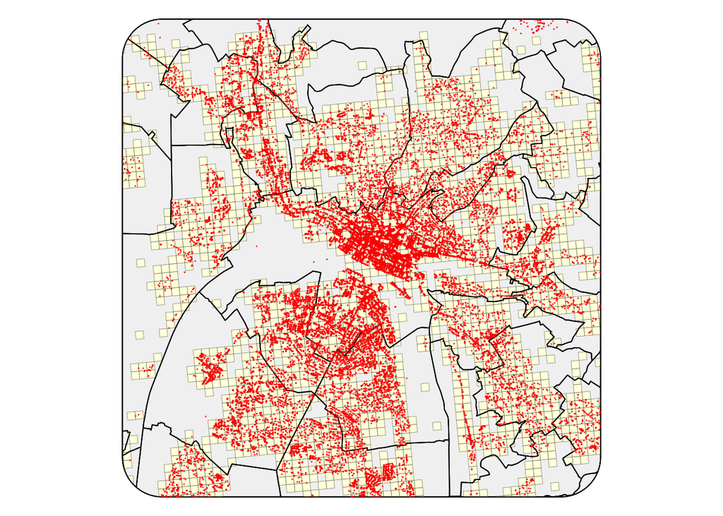

```r
mapgrid <- readRDS("data/mapgrid.RDS")
buffer <- readRDS("data/buffer.RDS")
mapcom <- readRDS("data/mapcom.RDS")
mapcom<-st_transform(mapcom, 2154) %>% st_intersection(buffer)

par(mar=c(0,0,0,0))
plot(buffer$geom, col="gray95")
plot(mapgrid$geom, add=T,  border="black",col="lightyellow",lwd=0.2)
plot(mapcom$geom, add=T, col=NA, border="black")
plot(dpe$geometry, add=T,col="red", pch=20, cex=0.1)
```

### Contenu du fichier

Ce dossier contient les données DPE de la zone d’étude Le nom des variables a été changé par rapport au fichier original, donc on charge le tableau des métadonnées et on l’affiche

```r
dpe_meta<-readRDS("data/dpe_meta.RDS")
kable(dpe_meta)
```

| var | label |
| --- | --- |
| id | Identififiant DPE |
| zone | Zone d’étude ou buffer |
| com_code | Code INSEE de la commune |
| com_name | Nom de la commune |
| iris_code | Code INSEE de l’IRIS |
| iris_name | Nom de l’IRIS |
| quart_code | Code INSEE du quartier |
| quart_name | Nom du quartier |
| idcar_200m | Code INSEE du carreau de 200m |
| dat | Ancienneté du bâtiment |
| per | Periode de construction |
| typ | Type de bâtiment |
| dpe | Classe DPE (A..G) |
| sup | Surface habitable du logement |
| con_tot | Consommation totale d’énergie primaire |
| con_m2 | Consommation totale d’énergie primaire par m2 |
| ene | Energie principale |
| geometry | Coordonnées géographiques |

### Sélection des unités et recodage des variables

On élimine les coordonnées géographiques et on retire les immeubles

```r
## Sélectionne les lignes et colonnes
don <- dpe %>% st_drop_geometry(dpe) %>%
                filter(typ != "immeuble") %>%   # Retire les appartements %>%       # Retire les logements de plus de 100 ans
                 mutate(idcar_200m =as.character(idcar_200m),
                        com_code = as.character(com_code),
                        com_name = as.character(com_name),
                       typ = as.factor(as.character(typ)) # Recode le type sans les immeubles
                  ) %>%
               select(idcar_200m,
                      com_code,
                      com_name,
                      dpe,
                      con_tot,
                      sup,
                      con_m2,
                      typ,
                      ene,
                      per)


## Elimine les données incomplètes
don <- don[complete.cases(don),]
```

### Ajout de variables contextuelles

On extrait de la grille 200m des variables contextuelles :

```r
context <- mapgrid %>% st_drop_geometry() %>%
                    filter(men>9) %>%
                   mutate(gri_logsoc = 100*log_soc/log,
                          gri_pauv = 100*men_pauv/men,
                          gri_prop = 100*men_prop/men,
                          gri_revenu = ind_snv/ind,
                          gri_vieux = 100*ind_65p/ind,
                          gri_jeunes = 100*ind_0_17/ind) %>%
                    select(idcar_200m, gri_logsoc,gri_pauv,gri_prop,gri_revenu,gri_vieux,gri_jeunes)

 summary(context)
```

```
  idcar_200m          gri_logsoc        gri_pauv         gri_prop
 Length:1686        Min.   :  0.00   Min.   : 0.000   Min.   :  0.00
 Class :character   1st Qu.:  0.00   1st Qu.: 4.167   1st Qu.: 30.27
 Mode  :character   Median :  0.00   Median : 8.949   Median : 65.83
                    Mean   : 21.25   Mean   :12.332   Mean   : 58.41
                    3rd Qu.: 34.92   3rd Qu.:17.507   3rd Qu.: 87.64
                    Max.   :100.00   Max.   :74.510   Max.   :100.00
   gri_revenu      gri_vieux       gri_jeunes
 Min.   :11692   Min.   : 0.00   Min.   : 0.00
 1st Qu.:20505   1st Qu.:13.72   1st Qu.:15.60
 Median :24364   Median :19.55   Median :20.00
 Mean   :24841   Mean   :21.37   Mean   :20.40
 3rd Qu.:28916   3rd Qu.:27.00   3rd Qu.:24.88
 Max.   :41550   Max.   :85.19   Max.   :48.39
```

Puis on ajoute ces variables contextuelles au tableau des dpe :

```r
don <- inner_join(don,context)
```

### Résumé de l’ensemble du tableau

```r
summary(don)
```

```
  idcar_200m          com_code           com_name         dpe
 Length:109565      Length:109565      Length:109565      A:  534
 Class :character   Class :character   Class :character   B: 4493
 Mode  :character   Mode  :character   Mode  :character   C:40578
                                                          D:32946
                                                          E:20301
                                                          F: 6546
                                                          G: 4167
    con_tot            sup              con_m2                typ
 Min.   :   890   Min.   :   5.60   Min.   :  24.9   appartement:94243
 1st Qu.:  7411   1st Qu.:  44.50   1st Qu.: 138.0   maison     :15322
 Median : 10504   Median :  62.30   Median : 195.0
 Mean   : 12574   Mean   :  62.44   Mean   : 213.3
 3rd Qu.: 15208   3rd Qu.:  75.80   3rd Qu.: 261.0
 Max.   :236530   Max.   :1565.50   Max.   :1603.0

                                      ene                per
 Gaz naturel                            :45114   1948-1974 :46026
 Électricité                            :31800   avant 1948:21581
 Réseau de Chauffage urbain             :30681   2013-2021 : 8597
 Fioul domestique                       : 1270   1989-2000 : 8288
 Bois – Bûches                          :  547   2006-2012 : 7868
 Bois – Granulés (pellets) ou briquettes:  106   1983-1988 : 4583
 (Other)                                :   47   (Other)   :12622
   gri_logsoc        gri_pauv        gri_prop        gri_revenu
 Min.   :  0.00   Min.   : 0.00   Min.   :  0.00   Min.   :12048
 1st Qu.:  0.00   1st Qu.:12.31   1st Qu.: 11.35   1st Qu.:17589
 Median : 28.61   Median :18.77   Median : 27.25   Median :20802
 Mean   : 39.66   Mean   :20.68   Mean   : 30.78   Mean   :21316
 3rd Qu.: 78.26   3rd Qu.:26.39   3rd Qu.: 43.78   3rd Qu.:24788
 Max.   :100.00   Max.   :62.65   Max.   :100.00   Max.   :41550

   gri_vieux       gri_jeunes
 Min.   : 0.00   Min.   : 0.00
 1st Qu.:11.71   1st Qu.:14.28
 Median :16.85   Median :19.74
 Mean   :18.00   Mean   :20.15
 3rd Qu.:22.71   3rd Qu.:25.00
 Max.   :85.19   Max.   :48.39
```

## (B) ANALYSE DE LA VARIABLE DEPENDANTE

On s’intéresse à la variable con_m2 qui est la consommation finale en Kwh/m2/an. Avant de l’utilise on doit s’assurer que sa distribution est approximativement gaussienne.

### La distribution de con_m2 est-elle normale ?

On fait un histogramme :

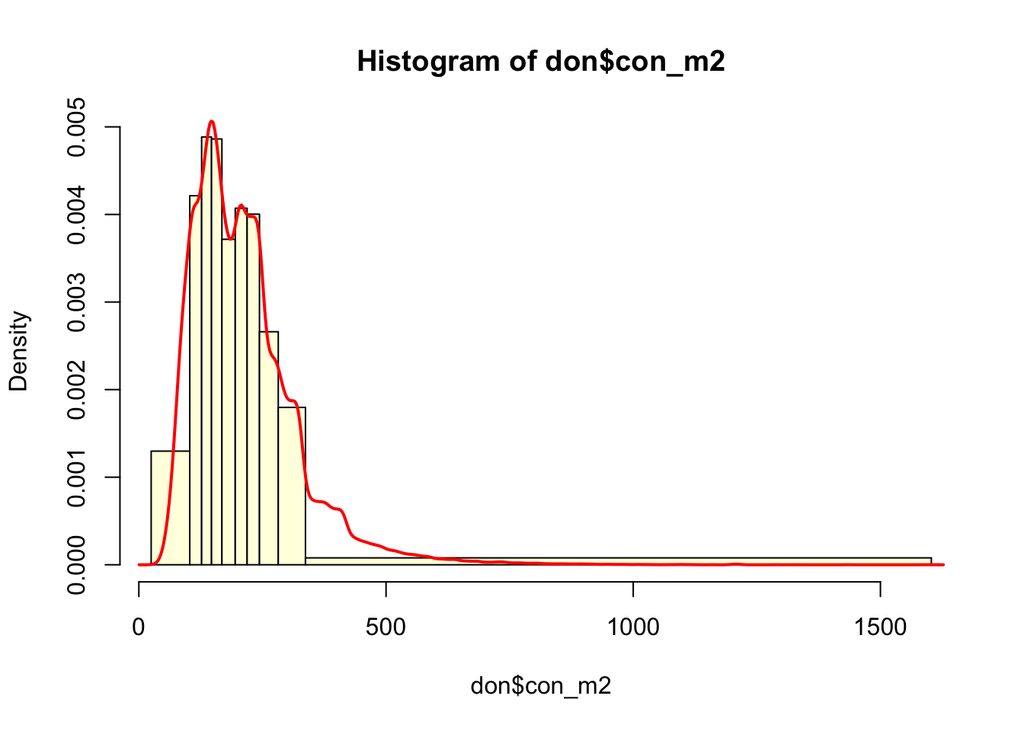

```r
hist(don$con_m2,
     breaks = quantile(don$con_m2,probs = seq(0,1,0.1)),
     col="lightyellow",
     probability = TRUE)
lines(density(don$con_m2),
      col="red",
      lwd=2)
```

La distribution n’est claiement pas symétrique.

Que nous apprend la boxplot ?

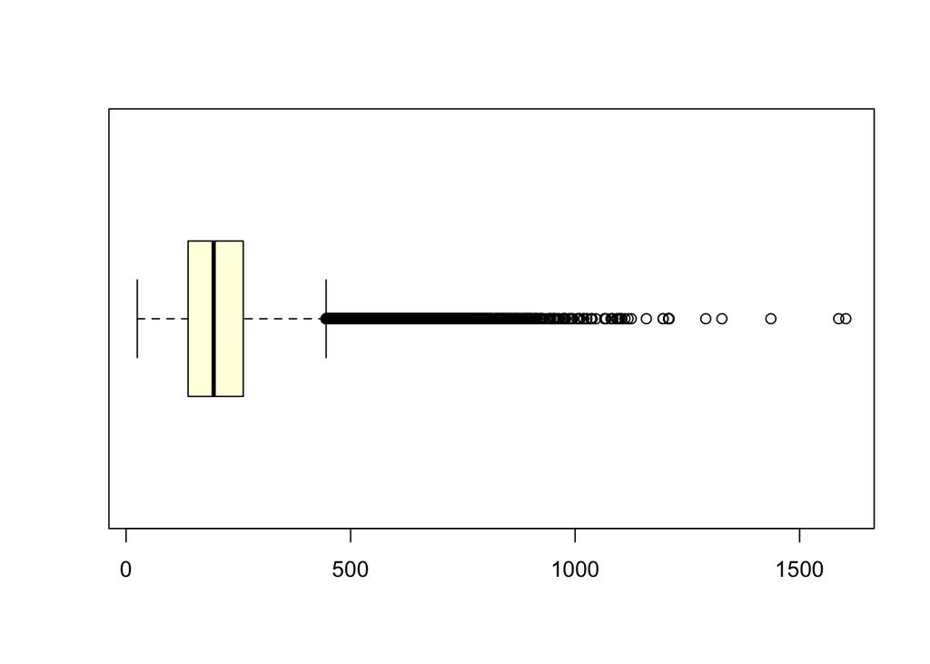

```r
boxplot(don$con_m2, col="lightyellow",horizontal = T)
```

Il y a un grand nombe de valeurs exceptionnelles à droite

Comme on veut garder toutes les valeurs, on passe en logarithme

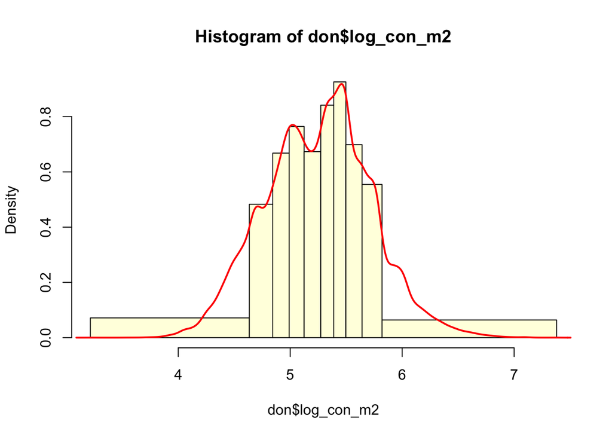

```r
don$log_con_m2<-log(don$con_m2)
hist(don$log_con_m2,
     breaks = quantile(don$log_con_m2,probs = seq(0,1,0.1)),
     col="lightyellow",
     probability = TRUE)
lines(density(don$log_con_m2),
      col="red",
      lwd=2)
```

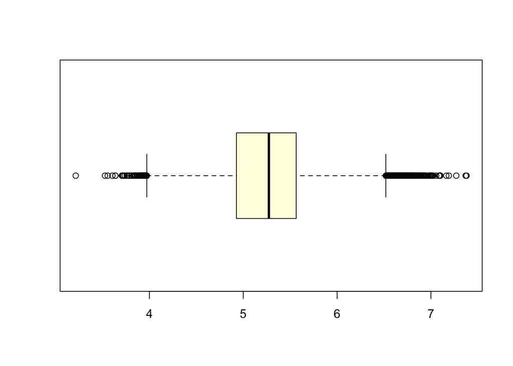

```r
boxplot(don$log_con_m2, col="lightyellow",horizontal = T)
```

Mais elle comporte toujours des valeurs exceptionnelles aux deux extrémités de la distribution cette-fois-ci.

## (C) REGRESSION LINEAIRE I : INTENSITE ENERGETIQUE ET SURFACE

Y-a-t-il une relation entre la surface du logement et l’intensité ? En d’autres termes les grands logements ont-ils la même intensité energétique que les petits.

### Diagramme

On fait le graphique

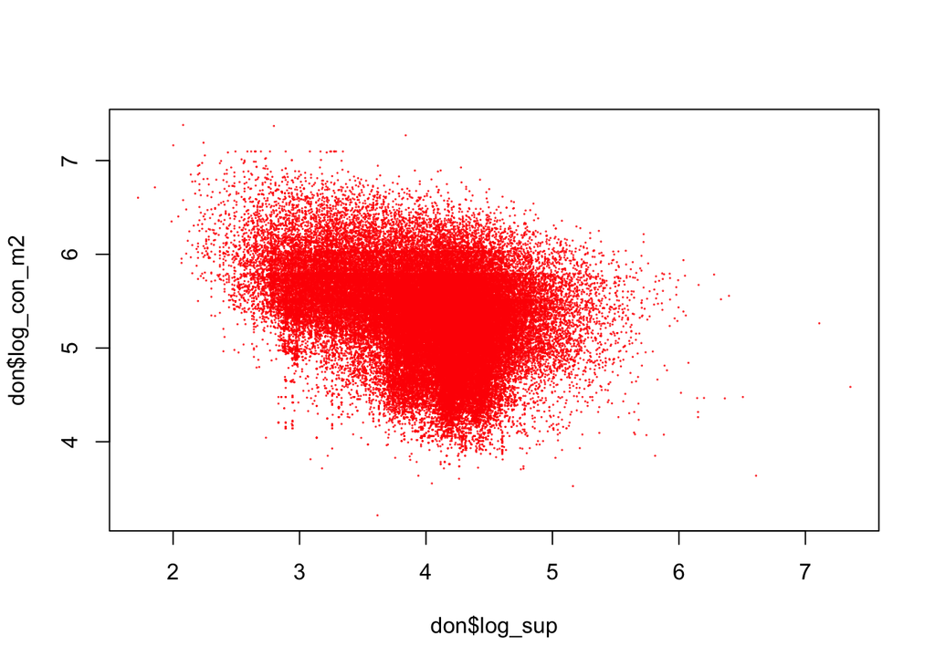

```r
don$log_sup<-log(don$sup)
plot(don$log_sup,don$log_con_m2, pch=20, cex=0.1, col="red")
```

### Corrélation

Puis on teste le coefficient de Pearson et celui de Sperman

```r
cor.test(don$sup,don$log_con_m2)
```

```
    Pearson's product-moment correlation

data:  don$sup and don$log_con_m2
t = -74.536, df = 109563, p-value < 2.2e-16
alternative hypothesis: true correlation is not equal to 0
95 percent confidence interval:
 -0.2253091 -0.2140381
sample estimates:
       cor
-0.2196809
```

```r
cor.test(don$sup,don$log_con_m2, method="spearman")
```

```
    Spearman's rank correlation rho

data:  don$sup and don$log_con_m2
S = 2.8287e+14, p-value < 2.2e-16
alternative hypothesis: true rho is not equal to 0
sample estimates:
       rho
-0.2903886
```

### Régression

On calcule le modèle de régression

```r
mareg<-lm(don$log_con_m2~don$log_sup)
summary(mareg)
```

```
Call:
lm(formula = don$log_con_m2 ~ don$log_sup)

Residuals:
     Min       1Q   Median       3Q      Max
-2.16025 -0.29259  0.00899  0.30159  1.96266

Coefficients:
             Estimate Std. Error t value Pr(>|t|)
(Intercept)  6.479773   0.011077   585.0   <2e-16 ***
don$log_sup -0.305464   0.002732  -111.8   <2e-16 ***
---
Signif. codes:  0 '***' 0.001 '**' 0.01 '*' 0.05 '.' 0.1 ' ' 1

Residual standard error: 0.4457 on 109563 degrees of freedom
Multiple R-squared:  0.1024,    Adjusted R-squared:  0.1024
F-statistic: 1.25e+04 on 1 and 109563 DF,  p-value: < 2.2e-16
```

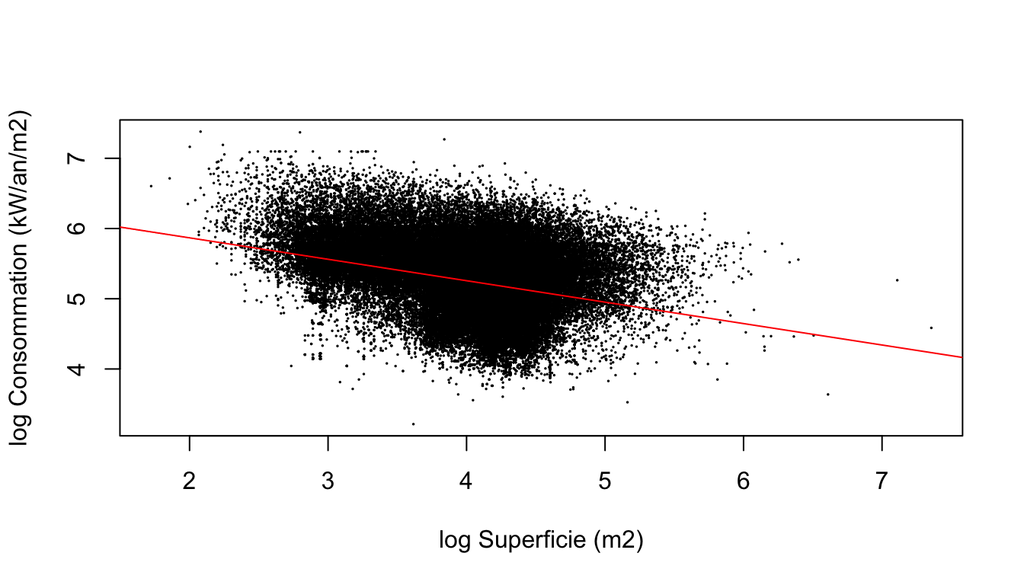

```r
plot(don$log_sup,don$log_con_m2, xlab="log Superficie (m2)",ylab = "log Consommation (kW/an/m2)",pch=19,cex=0.1)
abline(mareg,col="red",lwd=1)
```

### Conclusion

Le modèle nous indique que la consommation minimale est une fonction non-linéaire de la surface du logement.

On peut tracer le graphique correspondant

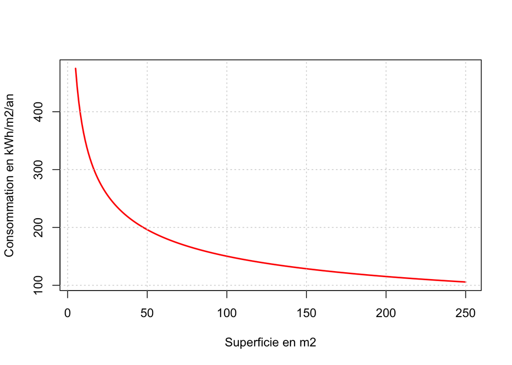

```r
X <- seq(5,250,1)
Y <- 881*(X**-0.384)
plot(X,Y, type="l",
     col="red",
     lwd=2,
     xlab="Superficie en m2",
     ylab = "Consommation en kWh/m2/an")
grid()
```

## (F) ANALYSE DE VARIANCE I : INTENSITE ENERGETIQUE ET TYPE DE LOGEMENT

### Hypothèses

On considère une variable **Y quantitative continue** définie sur une population de réféence P et une variable **X qualitative à deux modalités** divisant P en deux sous population P1 et P2.

Soit par exemple la variable Y = con_m2 et la variable X = typ. On peut se demander si les maisons ont une intensité énergétique supérieure à celle des appartements.

```r
Y<-don$log_con_m2
nomY <-"Consommation énergétique en kW/an/m2 (log)"

X<-don$typ
nomX <- "Type de logement"
```

### Visualisations

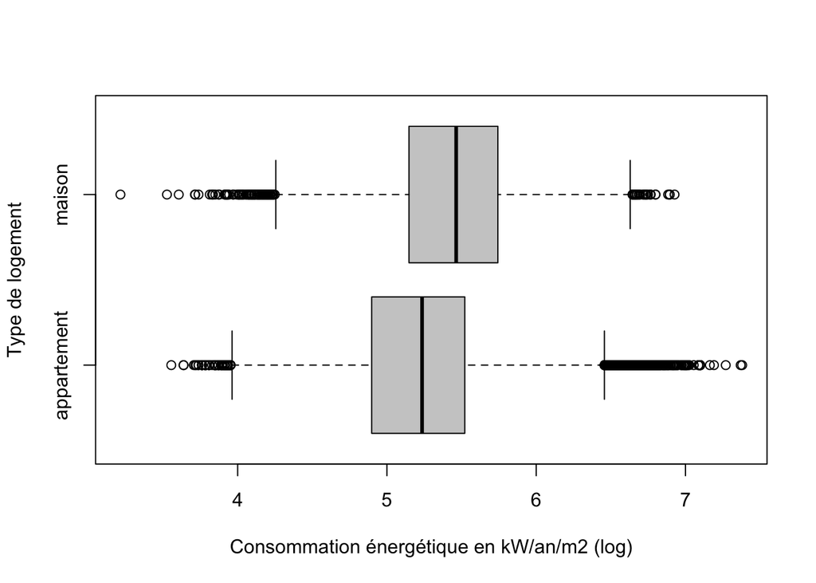

```r
boxplot(Y~X,horizontal=T, xlab = nomY, ylab=nomX, col="gray80")
```

### Paramètres principaux

On détermine la moyenne et l’écart-type de chaque échantillon avec la fonction tapply() couplée avec les fonctions mean(), sd() ou summary()

```r
tapply(Y,X, mean)
```

```
appartement      maison
   5.219498    5.442403
```

```r
tapply(Y,X,sd)
```

```
appartement      maison
  0.4678343   0.4397202
```

```r
tapply(Y,X, summary)
```

```
$appartement
   Min. 1st Qu.  Median    Mean 3rd Qu.    Max.
  3.555   4.898   5.235   5.219   5.521   7.380

$maison
   Min. 1st Qu.  Median    Mean 3rd Qu.    Max.
  3.215   5.147   5.464   5.442   5.743   6.927
```

### Modélisation

```r
modaov1<-lm(don$log_con_m2~don$typ)
summary(modaov1)
```

```
Call:
lm(formula = don$log_con_m2 ~ don$typ)

Residuals:
     Min       1Q   Median       3Q      Max
-2.22754 -0.32166  0.01694  0.30196  2.16013

Coefficients:
              Estimate Std. Error t value Pr(>|t|)
(Intercept)   5.219498   0.001511 3453.27   <2e-16 ***
don$typmaison 0.222905   0.004042   55.15   <2e-16 ***
---
Signif. codes:  0 '***' 0.001 '**' 0.01 '*' 0.05 '.' 0.1 ' ' 1

Residual standard error: 0.464 on 109563 degrees of freedom
Multiple R-squared:  0.02701,   Adjusted R-squared:  0.027
F-statistic:  3041 on 1 and 109563 DF,  p-value: < 2.2e-16
```

### Conclusion

Pour interpréter les coefficients on effectue une transformation exponentielle qui nous donne le taux d’accroissement par rapport à la période de départ.

```r
exp(modaov1$coefficients)
```

```
  (Intercept) don$typmaison
   184.841380      1.249702
```

## (G) ANALYSE DE VARIANCE II : INTENSITE ENERGETIQUE ET PERIODE DE CONSTRUCTION

### Hypothèses

On considère une variable **Y quantitative continue** définie sur une population de réféence P et une variable **X qualitative à k modalités** divisant P en k sous population P1…Pk.

Soit par exemple la variable Y = con_m2 et la variable X = Période de construction. X ressemble à la variable ancienneté mais elle est exprimée sous forme qualitative

```r
table(don$per)
```

```
avant 1948  1948-1974  1975-1977  1978-1982  1983-1988  1989-2000  2001-2005
     21581      46026       4338       4428       4583       8288       3427
 2006-2012  2013-2021 après 2021
      7868       8597        429
```

### Calcul des paramètres principaux

tapply(*variable à analyser, variable de partition , function*)

La fonction **tapply()** s’applique sur les tableaux (*data.frame*). Il y a des fonctions équvalentes pour les listes, les matrices, etc…

```r
moy<-tapply(X = don$log_con_m2, INDEX = don$per, FUN = mean)
moy
```

```
avant 1948  1948-1974  1975-1977  1978-1982  1983-1988  1989-2000  2001-2005
  5.670655   5.274770   5.168568   5.094433   5.132945   5.189096   5.037606
 2006-2012  2013-2021 après 2021
  5.028388   4.630944   4.625499
```

```r
ect<-tapply(don$log_con_m2, don$per, sd)
ect
```

```
avant 1948  1948-1974  1975-1977  1978-1982  1983-1988  1989-2000  2001-2005
 0.3855417  0.4125756  0.3717470  0.3836335  0.3724697  0.3423315  0.3596504
 2006-2012  2013-2021 après 2021
 0.3269827  0.3256592  0.4010218
```

```r
100*ect/moy
```

```
avant 1948  1948-1974  1975-1977  1978-1982  1983-1988  1989-2000  2001-2005
  6.798892   7.821680   7.192457   7.530446   7.256452   6.597132   7.139310
 2006-2012  2013-2021 après 2021
  6.502735   7.032241   8.669806
```

```r
tapply(don$log_con_m2, don$per, summary)
```

```
$`avant 1948`
   Min. 1st Qu.  Median    Mean 3rd Qu.    Max.
  3.716   5.425   5.659   5.671   5.908   7.380

$`1948-1974`
   Min. 1st Qu.  Median    Mean 3rd Qu.    Max.
  3.706   4.990   5.308   5.275   5.545   6.985

$`1975-1977`
   Min. 1st Qu.  Median    Mean 3rd Qu.    Max.
  4.055   4.883   5.204   5.169   5.421   6.733

$`1978-1982`
   Min. 1st Qu.  Median    Mean 3rd Qu.    Max.
  3.605   4.794   5.094   5.094   5.342   6.538

$`1983-1988`
   Min. 1st Qu.  Median    Mean 3rd Qu.    Max.
  4.018   4.875   5.106   5.133   5.421   6.407

$`1989-2000`
   Min. 1st Qu.  Median    Mean 3rd Qu.    Max.
  3.716   4.934   5.215   5.189   5.442   6.422

$`2001-2005`
   Min. 1st Qu.  Median    Mean 3rd Qu.    Max.
  4.094   4.813   5.017   5.038   5.236   6.563

$`2006-2012`
   Min. 1st Qu.  Median    Mean 3rd Qu.    Max.
  3.898   4.796   5.030   5.028   5.273   6.342

$`2013-2021`
   Min. 1st Qu.  Median    Mean 3rd Qu.    Max.
  3.215   4.419   4.595   4.631   4.844   6.220

$`après 2021`
   Min. 1st Qu.  Median    Mean 3rd Qu.    Max.
  3.714   4.341   4.543   4.625   4.836   5.951
```

### Visualisation

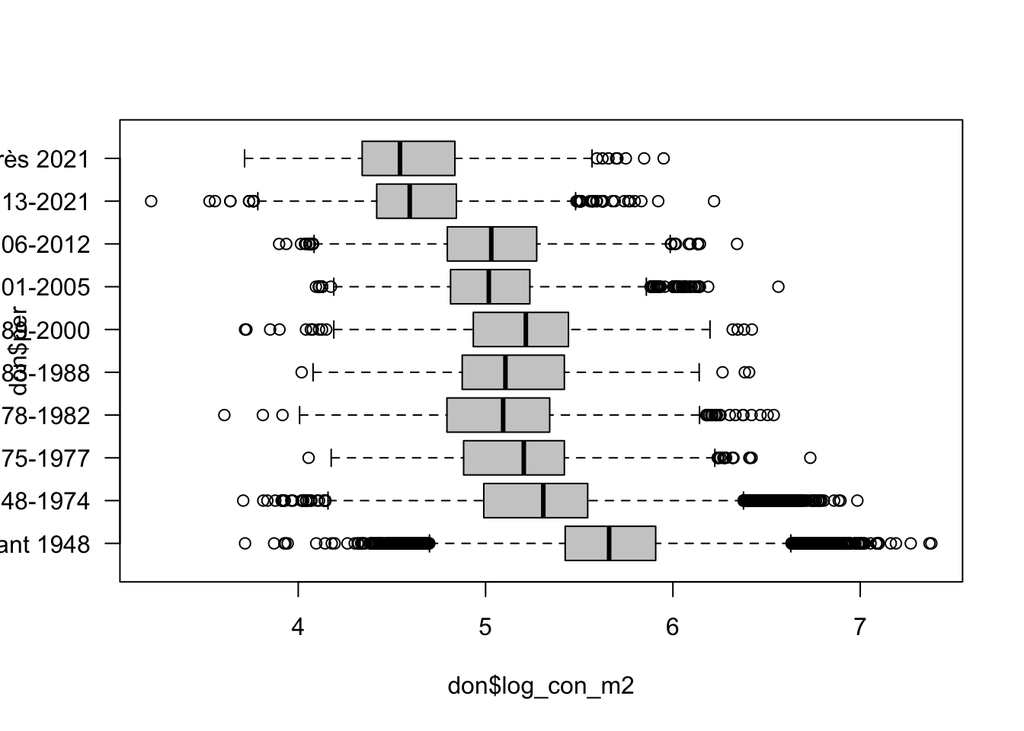

```r
boxplot(don$log_con_m2~don$per, col="gray80",horizontal=T,las=T)
```

### Modélisation

```r
modaov2<-lm(don$log_con_m2~don$per)
summary(modaov2)
```

```
Call:
lm(formula = don$log_con_m2 ~ don$per)

Residuals:
     Min       1Q   Median       3Q      Max
-1.95465 -0.26413  0.00843  0.25186  1.70995

Coefficients:
                   Estimate Std. Error t value Pr(>|t|)
(Intercept)        5.670655   0.002615 2168.72   <2e-16 ***
don$per1948-1974  -0.395885   0.003169 -124.92   <2e-16 ***
don$per1975-1977  -0.502087   0.006391  -78.56   <2e-16 ***
don$per1978-1982  -0.576222   0.006337  -90.93   <2e-16 ***
don$per1983-1988  -0.537709   0.006247  -86.07   <2e-16 ***
don$per1989-2000  -0.481559   0.004964  -97.01   <2e-16 ***
don$per2001-2005  -0.633048   0.007063  -89.62   <2e-16 ***
don$per2006-2012  -0.642267   0.005059 -126.97   <2e-16 ***
don$per2013-2021  -1.039710   0.004899 -212.23   <2e-16 ***
don$peraprès 2021 -1.045155   0.018729  -55.80   <2e-16 ***
---
Signif. codes:  0 '***' 0.001 '**' 0.01 '*' 0.05 '.' 0.1 ' ' 1

Residual standard error: 0.3841 on 109555 degrees of freedom
Multiple R-squared:  0.3333,    Adjusted R-squared:  0.3332
F-statistic:  6084 on 9 and 109555 DF,  p-value: < 2.2e-16
```

### Conclusion

Pour interpréter les coefficients on effectue une transformation exponentielle qui nous donne le taux d’accroissement par rapport à la période de départ.

```r
exp(modaov2$coefficients)
```

```
      (Intercept)  don$per1948-1974  don$per1975-1977  don$per1978-1982
      290.2244651         0.6730841         0.6052663         0.5620178
 don$per1983-1988  don$per1989-2000  don$per2001-2005  don$per2006-2012
        0.5840846         0.6178197         0.5309709         0.5260984
 don$per2013-2021 don$peraprès 2021
        0.3535571         0.3516373
```

## (G) ANALYSE DE VARIANCE III : INTENSITE ENERGETIQUE ET TYPE DE COMBUSTIBLE

### Hypothèses

```r
table(don$ene)
```

```
                                               Bois – Bûches
                                                         547
                     Bois – Granulés (pellets) ou briquettes
                                                         106
                               Bois – Plaquettes forestières
                                                           2
                                                     Charbon
                                                           4
                                                 Électricité
                                                       31800
Électricité d'origine renouvelable utilisée dans le bâtiment
                                                           2
                                            Fioul domestique
                                                        1270
                                                 Gaz naturel
                                                       45114
                                                         GPL
                                                          37
                                                     Propane
                                                           1
                                  Réseau de Chauffage urbain
                                                       30681
                                      Réseau de Froid Urbain
                                                           1
```

On procède à un regroupement en trois grands types

```r
don$ene3<-don$ene
levels(don$ene3) <- c( "Hydroc."   ,
 "Hydroc."      ,
 "Hydroc."       ,
 "Hydroc."        ,
 "Élect."      ,
 "Élect.",
"Hydroc."     ,
"Hydroc."         ,
"Hydroc."          ,
"Hydroc."           ,
 "Rés.urb."             ,
 "Rés.urb." )
table(don$ene3)
```

```
 Hydroc.   Élect. Rés.urb.
   47081    31802    30682
```

### Calcul des paramètres principaux

tapply(*variable à analyser, variable de partition , function*)

La fonction **tapply()** s’applique sur les tableaux (*data.frame*). Il y a des fonctions équvalentes pour les listes, les matrices, etc…

```r
moy<-tapply(X = don$log_con_m2, INDEX = don$ene3, FUN = mean)
moy
```

```
 Hydroc.   Élect. Rés.urb.
5.201342 5.521019 5.046144
```

```r
ect<-tapply(don$log_con_m2, don$ene3, sd)
ect
```

```
  Hydroc.    Élect.  Rés.urb.
0.4750929 0.4249620 0.3678639
```

```r
100*ect/moy
```

```
 Hydroc.   Élect. Rés.urb.
9.134045 7.697166 7.290000
```

```r
tapply(don$con_m2, don$ene3, summary)
```

```
$Hydroc.
   Min. 1st Qu.  Median    Mean 3rd Qu.    Max.
   42.0   128.0   186.0   203.1   256.0  1208.6

$Élect.
   Min. 1st Qu.  Median    Mean 3rd Qu.    Max.
   24.9   196.0   246.2   273.6   320.0  1603.0

$Rés.urb.
   Min. 1st Qu.  Median    Mean 3rd Qu.    Max.
   38.0   120.0   153.6   166.3   206.0   753.0
```

### Visualisation

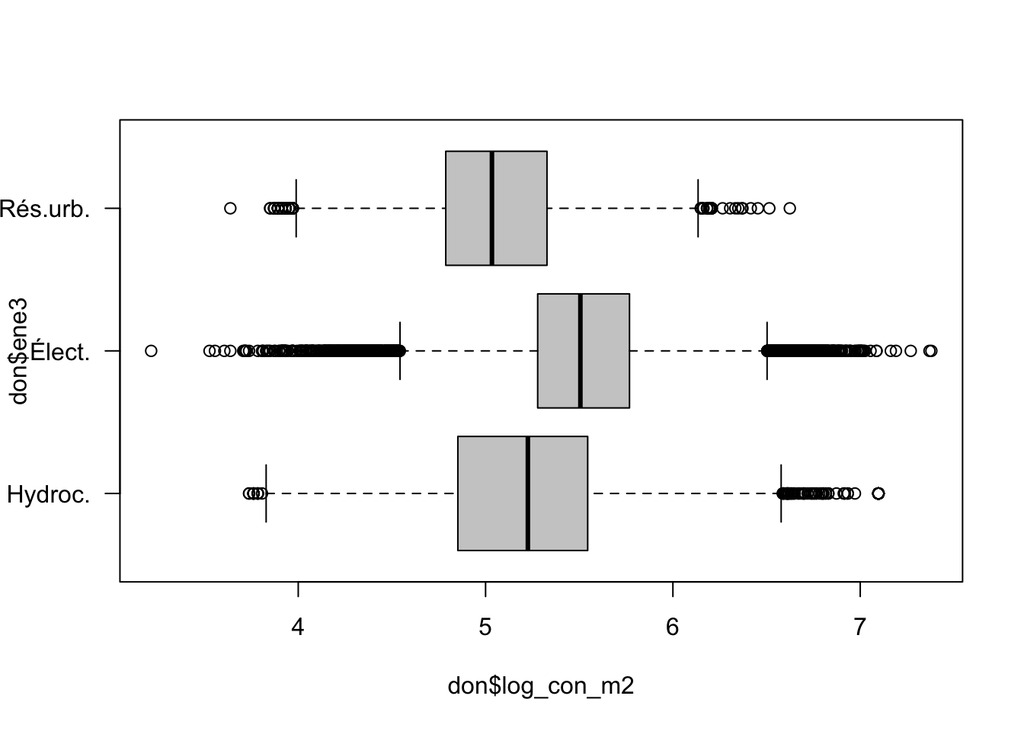

```r
boxplot(don$log_con_m2~don$ene3, col="gray80",horizontal=T,las=T)
```

### Modélisation

```r
modaov3<-lm(log_con_m2~ene3, data=don)
summary(modaov3)
```

```
Call:
lm(formula = log_con_m2 ~ ene3, data = don)

Residuals:
     Min       1Q   Median       3Q      Max
-2.30615 -0.28869 -0.00357  0.29091  1.89588

Coefficients:
              Estimate Std. Error t value Pr(>|t|)
(Intercept)   5.201342   0.001995 2607.74   <2e-16 ***
ene3Élect.    0.319677   0.003141  101.76   <2e-16 ***
ene3Rés.urb. -0.155198   0.003175  -48.88   <2e-16 ***
---
Signif. codes:  0 '***' 0.001 '**' 0.01 '*' 0.05 '.' 0.1 ' ' 1

Residual standard error: 0.4328 on 109562 degrees of freedom
Multiple R-squared:  0.1535,    Adjusted R-squared:  0.1535
F-statistic:  9937 on 2 and 109562 DF,  p-value: < 2.2e-16
```

### Conclusion

On calcule l’exponentiel des coefficients pour obtenir l’effet multiplicatif

```r
exp(modaov2$coefficients)
```

[output not shown]

## (H) MODELE FINAL

### Régression

On reprend toutes nos variables explicatives qualitatives ou quantitatives dans un seul modèle mais en retirant l’ancienneté puisque l’on a mis les périodes de temps

```r
modfin<-lm(don$log_con_m2~don$log_sup +  don$typ + don$per + don$ene3)
summary(modfin)
```

```
Call:
lm(formula = don$log_con_m2 ~ don$log_sup + don$typ + don$per +
    don$ene3)

Residuals:
     Min       1Q   Median       3Q      Max
-2.33715 -0.20646 -0.00472  0.22806  1.59157

Coefficients:
                   Estimate Std. Error t value Pr(>|t|)
(Intercept)        6.390843   0.010360  616.89   <2e-16 ***
don$log_sup       -0.230676   0.002566  -89.90   <2e-16 ***
don$typmaison      0.222551   0.003461   64.29   <2e-16 ***
don$per1948-1974  -0.152367   0.003218  -47.35   <2e-16 ***
don$per1975-1977  -0.281011   0.005861  -47.95   <2e-16 ***
don$per1978-1982  -0.348379   0.005822  -59.84   <2e-16 ***
don$per1983-1988  -0.342656   0.005722  -59.89   <2e-16 ***
don$per1989-2000  -0.385170   0.004489  -85.81   <2e-16 ***
don$per2001-2005  -0.513283   0.006363  -80.67   <2e-16 ***
don$per2006-2012  -0.484063   0.004633 -104.49   <2e-16 ***
don$per2013-2021  -0.832283   0.004600 -180.94   <2e-16 ***
don$peraprès 2021 -0.945988   0.016719  -56.58   <2e-16 ***
don$ene3Élect.     0.172869   0.002811   61.50   <2e-16 ***
don$ene3Rés.urb.  -0.145664   0.002731  -53.34   <2e-16 ***
---
Signif. codes:  0 '***' 0.001 '**' 0.01 '*' 0.05 '.' 0.1 ' ' 1

Residual standard error: 0.3425 on 109551 degrees of freedom
Multiple R-squared:  0.4699,    Adjusted R-squared:  0.4698
F-statistic:  7469 on 13 and 109551 DF,  p-value: < 2.2e-16
```

```r
anova(modfin)
```

```
Analysis of Variance Table

Response: don$log_con_m2
                Df  Sum Sq Mean Sq F value    Pr(>F)
don$log_sup      1  2482.2 2482.16 21157.3 < 2.2e-16 ***
don$typ          1  2127.5 2127.46 18133.9 < 2.2e-16 ***
don$per          9  5727.1  636.35  5424.1 < 2.2e-16 ***
don$ene3         2  1054.7  527.33  4494.8 < 2.2e-16 ***
Residuals   109551 12852.4    0.12
---
Signif. codes:  0 '***' 0.001 '**' 0.01 '*' 0.05 '.' 0.1 ' ' 1
```

```r
exp(modfin$coefficients)
```

```
      (Intercept)       don$log_sup     don$typmaison  don$per1948-1974
      596.3591601         0.7939968         1.2492590         0.8586734
 don$per1975-1977  don$per1978-1982  don$per1983-1988  don$per1989-2000
        0.7550201         0.7058317         0.7098826         0.6803350
 don$per2001-2005  don$per2006-2012  don$per2013-2021 don$peraprès 2021
        0.5985275         0.6162746         0.4350547         0.3882958
   don$ene3Élect.  don$ene3Rés.urb.
        1.1887105         0.8644485
```

### Analyse de variance

On vérifie que toutes les variables sont significatives à l’aide d’une analyse de variance :

```r
anova(modfin)
```

```
Analysis of Variance Table

Response: don$log_con_m2
                Df  Sum Sq Mean Sq F value    Pr(>F)
don$log_sup      1  2482.2 2482.16 21157.3 < 2.2e-16 ***
don$typ          1  2127.5 2127.46 18133.9 < 2.2e-16 ***
don$per          9  5727.1  636.35  5424.1 < 2.2e-16 ***
don$ene3         2  1054.7  527.33  4494.8 < 2.2e-16 ***
Residuals   109551 12852.4    0.12
---
Signif. codes:  0 '***' 0.001 '**' 0.01 '*' 0.05 '.' 0.1 ' ' 1
```

Toutes les variables sont significatives et le modèle résumé 47% de la variance totale.

### Paramètres

On calcule l’exponentiel des coefficients pour les interpréter :

```r
exp(modfin$coefficients)
```

```
      (Intercept)       don$log_sup     don$typmaison  don$per1948-1974
      596.3591601         0.7939968         1.2492590         0.8586734
 don$per1975-1977  don$per1978-1982  don$per1983-1988  don$per1989-2000
        0.7550201         0.7058317         0.7098826         0.6803350
 don$per2001-2005  don$per2006-2012  don$per2013-2021 don$peraprès 2021
        0.5985275         0.6162746         0.4350547         0.3882958
   don$ene3Élect.  don$ene3Rés.urb.
        1.1887105         0.8644485
```

On peut résumernos découvertes comme suit :

**Toutes choses égales quant aux autre variables …**

### Calcul des résidus

On peut ajouter à notre tableau des logements la consommation théorique (con_m2_EST) déduite du modèle et la consommation résiduelle (con_m2_RES).

On calcule ensuite **l’erreur relative en %** :

$ERR = 100 \times (\frac{OBS}{EST}-1)$

```r
don$con_m2_EST <-exp(modfin$fitted.values)
don$con_m2_RES <- 100*((don$con_m2/don$con_m2_EST)-1)
```

On peut alors examiner les logements qui s’écartent le plus des prédictions du modèle positivement ou négativement.

### Résidus négatifs

```r
tabres<- don %>% arrange(con_m2_RES) %>% select(3,6,8,19,10,7,20,21,4)
kable(head(tabres,10))
```

| com_name | sup | typ | ene3 | per | con_m2 | con_m2_EST | con_m2_RES | dpe |
| --- | --- | --- | --- | --- | --- | --- | --- | --- |
| Rouen | 24.0 | maison | Élect. | avant 1948 | 41.1 | 425.4565 | -90.33979 | E |
| Rouen | 21.9 | maison | Élect. | 1948-1974 | 45.3 | 373.1268 | -87.85936 | E |
| Rouen | 26.0 | maison | Élect. | 1948-1974 | 50.8 | 358.6447 | -85.83556 | E |
| Le Petit-Quevilly | 37.2 | maison | Élect. | 2013-2021 | 24.9 | 167.2993 | -85.11649 | C |
| Rouen | 70.9 | maison | Élect. | 1978-1982 | 36.8 | 233.9044 | -84.26707 | C |
| Darnétal | 97.7 | maison | Élect. | avant 1948 | 50.7 | 307.7627 | -83.52627 | A |
| Darnétal | 101.2 | maison | Élect. | avant 1948 | 51.6 | 305.2740 | -83.09715 | A |
| Bois-Guillaume | 70.7 | maison | Hydroc. | avant 1948 | 48.0 | 278.9614 | -82.79332 | B |
| Bois-Guillaume | 95.0 | maison | Élect. | 1948-1974 | 46.3 | 265.9816 | -82.59278 | F |
| Le Petit-Quevilly | 96.0 | maison | Élect. | 1948-1974 | 50.3 | 265.3399 | -81.04318 | D |

On trouve plusieurs cas de maisons anciennes ou appartements de petite superficie chauffées à l’électricité qui cumulent les désavantage et devraient avoir une intensité énergétique de 300 W/an/m2 selon notre modèle. Or, elles affichent une consommation beaucoup plus réduite de moins de 100 kW/an/m2. S’agit-il de logements rénovés ? Ou bien le diagnostic était-il douteux ?

### Résidus positifs

```r
tabres <- tabres %>% arrange(-con_m2_RES)
kable(head(tabres,10))
```

| com_name | sup | typ | ene3 | per | con_m2 | con_m2_EST | con_m2_RES | dpe |
| --- | --- | --- | --- | --- | --- | --- | --- | --- |
| Rouen | 46.5 | appartement | Élect. | avant 1948 | 1436.0 | 292.3768 | 391.1470 | G |
| Rouen | 28.3 | appartement | Hydroc. | avant 1948 | 1208.6 | 275.8137 | 338.1943 | G |
| Rouen | 39.2 | appartement | Hydroc. | 1975-1977 | 840.0 | 193.1674 | 334.8559 | G |
| Rouen | 26.8 | appartement | Hydroc. | avant 1948 | 1208.6 | 279.3005 | 332.7238 | G |
| Rouen | 26.5 | appartement | Hydroc. | avant 1948 | 1208.6 | 280.0268 | 331.6016 | G |
| Rouen | 26.4 | appartement | Hydroc. | avant 1948 | 1208.6 | 280.2711 | 331.2254 | G |
| Rouen | 25.8 | appartement | Hydroc. | avant 1948 | 1208.6 | 281.7613 | 328.9446 | G |
| Rouen | 55.0 | appartement | Rés.urb. | 1948-1974 | 753.0 | 175.6368 | 328.7256 | G |
| Rouen | 25.6 | appartement | Hydroc. | avant 1948 | 1208.6 | 282.2676 | 328.1753 | G |
| Rouen | 16.4 | appartement | Élect. | avant 1948 | 1587.0 | 371.8338 | 326.8035 | G |

A l’inverse du cas précédent, on trouve ici des appartements, assez anciens (avant 1948) qui ne sont pas chauffés à l’élecricité et devraient avoir une consommation faible. Mais qui en fait sont des passoires énergétiques pour une raison qui reste à expliquer. Les valeurs de consommation observées semblent toutefois assez étonnantes (>1000 kWh/m2/an)

### Y-a-t-il un effet communal ?

Au terme de l’analyse on peut se demander si les résidus positifs et négatifs se concentrent plutôt dans certaines communes. Il suffit pour cela d’agréger les valeurs observées, estimées et résiduelles, par exemple en en faisant la moyenne.

```r
res_com <- don %>% group_by(com_code,com_name) %>%
                      summarise(n =n(),
                                OBS = median(con_m2),
                                EST = median(con_m2_EST),
                                RES = median(con_m2_RES)) %>%
                      arrange(RES) %>%
                      filter(n > 100)
kable(res_com, digits=2)
```

| com_code | com_name | n | OBS | EST | RES |
| --- | --- | --- | --- | --- | --- |
| 76157 | Canteleu | 4780 | 145.00 | 167.82 | -13.61 |
| 76212 | Darnétal | 3279 | 154.00 | 172.15 | -12.88 |
| 76216 | Déville-lès-Rouen | 2857 | 163.00 | 196.20 | -11.26 |
| 76599 | Saint-Léger-du-Bourg-Denis | 602 | 136.00 | 192.18 | -10.91 |
| 76095 | Bihorel | 1917 | 155.10 | 171.88 | -7.88 |
| 76497 | Petit-Couronne | 2003 | 180.00 | 193.23 | -7.57 |
| 76475 | Franqueville-Saint-Pierre | 386 | 161.60 | 171.71 | -5.99 |
| 76575 | Saint-Étienne-du-Rouvray | 4026 | 162.00 | 172.01 | -5.54 |
| 76005 | Amfreville-la-Mi-Voie | 1022 | 160.80 | 159.58 | -4.87 |
| 76322 | Le Grand-Quevilly | 11802 | 161.00 | 169.48 | -3.36 |
| 76410 | Maromme | 4129 | 163.00 | 169.60 | -1.16 |
| 76498 | Le Petit-Quevilly | 4130 | 183.00 | 177.38 | 0.16 |
| 76429 | Le Mesnil-Esnard | 1321 | 165.00 | 167.91 | 1.55 |
| 76108 | Bois-Guillaume | 2765 | 188.00 | 178.61 | 2.50 |
| 76540 | Rouen | 51514 | 221.00 | 204.07 | 3.46 |
| 76474 | Notre-Dame-de-Bondeville | 1257 | 213.00 | 201.69 | 3.61 |
| 76103 | Bonsecours | 1200 | 201.65 | 189.32 | 3.78 |
| 76681 | Sotteville-lès-Rouen | 6549 | 223.00 | 199.14 | 9.65 |
| 76617 | Saint-Martin-du-Vivier | 122 | 231.50 | 208.24 | 11.47 |
| 76451 | Mont-Saint-Aignan | 3640 | 197.80 | 174.35 | 11.58 |

### Y-a-t-il un effet local

```r
res_grid <- don %>% group_by(idcar_200m) %>%
                      summarise(n =n(),
                                com_name = min(com_name),
                                OBS = median(con_m2),
                                EST = median(con_m2_EST),
                                RES = median(con_m2_RES),
                                gri_logsoc=mean(gri_logsoc),
                                gri_pauv=mean(gri_pauv),
                                gri_prop = mean(gri_prop),
                                gri_revenu = mean(gri_revenu),
                                gri_vieux = mean(gri_vieux),
                                gri_jeune = mean(gri_jeunes)) %>%
                      arrange(RES) %>%
                      filter(n > 4)
```

Si notre modèle est correct, on déduit de l’analyse que certains lieux sont plus ou moins énergivores que prévu, toutes choses égales quant aux variables contrôlées.

On peut examiner les 10 grilles les plus energivores

```r
res_grid <- res_grid %>% arrange(-RES)
kable(head(res_grid[,-1],10), digits=1)
```

| n | com_name | OBS | EST | RES | gri_logsoc | gri_pauv | gri_prop | gri_revenu | gri_vieux | gri_jeune |
| --- | --- | --- | --- | --- | --- | --- | --- | --- | --- | --- |
| 127 | Maromme | 175.0 | 84.9 | 100.0 | 67.6 | 19.4 | 18.0 | 18536.7 | 11.7 | 27.5 |
| 106 | Bihorel | 307.0 | 160.4 | 91.4 | 59.1 | 16.3 | 33.5 | 18075.5 | 17.0 | 29.9 |
| 17 | Canteleu | 247.0 | 135.7 | 89.2 | 0.0 | 4.7 | 82.1 | 24990.5 | 46.5 | 9.2 |
| 5 | Rouen | 397.0 | 239.0 | 82.3 | 8.0 | 20.0 | 64.0 | 21085.5 | 19.2 | 25.0 |
| 5 | Saint-Étienne-du-Rouvray | 341.8 | 199.2 | 72.5 | 15.8 | 12.3 | 70.2 | 22897.4 | 21.2 | 14.3 |
| 53 | Maromme | 199.0 | 119.7 | 66.2 | 5.6 | 8.3 | 18.1 | 20734.1 | 18.3 | 21.1 |
| 136 | Le Grand-Quevilly | 306.0 | 186.2 | 65.8 | 64.5 | 9.2 | 32.9 | 23518.8 | 27.5 | 17.4 |
| 6 | Belbeuf | 385.5 | 224.8 | 65.6 | 0.0 | 7.7 | 76.9 | 29669.9 | 22.2 | 14.8 |
| 5 | Maromme | 325.0 | 196.9 | 65.1 | 82.6 | 28.3 | 17.4 | 17059.8 | 9.9 | 33.6 |
| 5 | Amfreville-la-Mi-Voie | 405.0 | 244.7 | 62.9 | 0.0 | 8.3 | 66.7 | 25351.9 | 8.0 | 16.0 |

```r
res_grid <- res_grid %>% arrange(RES)
kable(head(res_grid[,-1],10), digits=1)
```

| n | com_name | OBS | EST | RES | gri_logsoc | gri_pauv | gri_prop | gri_revenu | gri_vieux | gri_jeune |
| --- | --- | --- | --- | --- | --- | --- | --- | --- | --- | --- |
| 84 | Sotteville-lès-Rouen | 76.6 | 186.9 | -60.0 | 69.8 | 40.5 | 26.2 | 16988.4 | 17.7 | 21.7 |
| 500 | Rouen | 86.0 | 200.7 | -57.2 | 52.5 | 11.5 | 27.0 | 20663.5 | 26.0 | 17.3 |
| 260 | Saint-Étienne-du-Rouvray | 85.7 | 183.0 | -56.3 | 75.5 | 55.3 | 10.0 | 13235.4 | 8.4 | 36.0 |
| 60 | Canteleu | 74.5 | 158.9 | -54.4 | 90.5 | 17.5 | 0.0 | 17635.2 | 22.8 | 30.5 |
| 70 | Saint-Etienne-du-Rouvray | 90.0 | 197.3 | -53.8 | 91.2 | 18.7 | 8.8 | 17299.1 | 8.4 | 32.6 |
| 205 | Rouen | 96.0 | 201.5 | -52.3 | 57.7 | 14.8 | 19.3 | 20470.7 | 30.5 | 11.3 |
| 521 | Canteleu | 81.0 | 166.1 | -51.2 | 99.5 | 38.1 | 0.3 | 14670.4 | 15.1 | 29.0 |
| 31 | Sotteville-lès-Rouen | 97.7 | 196.2 | -48.3 | 0.0 | 10.9 | 71.7 | 26663.1 | 19.3 | 14.2 |
| 66 | Saint-Étienne-du-Rouvray | 98.0 | 212.2 | -47.7 | 100.0 | 31.9 | 0.0 | 15377.8 | 14.4 | 27.5 |
| 91 | Mont-Saint-Aignan | 101.0 | 187.0 | -47.6 | 62.5 | 11.6 | 33.0 | 24967.2 | 15.5 | 19.7 |

## (I) CARTOGRAPHIE DES EFFETS STRUCTURELS ET RESIDUELS

Nous terminons notre analyse par la création de trois cartes :

```r
mapgrid2 <- mapgrid %>% inner_join(res_grid)
```

### Consommation observée

C’est la carte des consommations médianes observées par carreaux de grille de 200m.

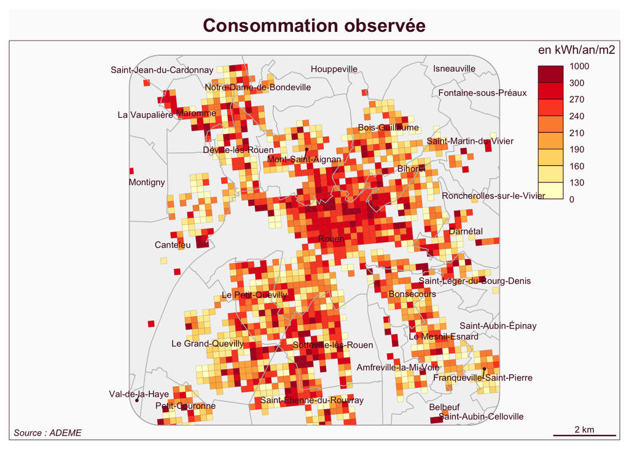

```r
mypal<-brewer.pal(8,"YlOrRd")
mybreaks <-c(00,130, 160, 190, 210, 240, 270, 300, 1000)
mf_map(buffer, type="base", col="gray95")
mf_map(mapgrid2,
       type = "choro",
       var = "OBS",
       pal=mypal,
       breaks = mybreaks,
       leg_title = "en kWh/an/m2",
       leg_val_rnd = 0,
       lwd=0.1,
       add=T)
mf_map(mapcom, type="base", col=NA, border="gray",add=T)
mf_label(mapcom,var = "NOM",cex = 0.6,overlap = F )
mf_layout(title = "Consommation observée",scale = T, arrow=F, frame=T,credits = "Source : ADEME")
```

### Consommation théorique

C’est la carte des consommations médianes théoriques par carreaux de grille de 200m selon notre modèle.

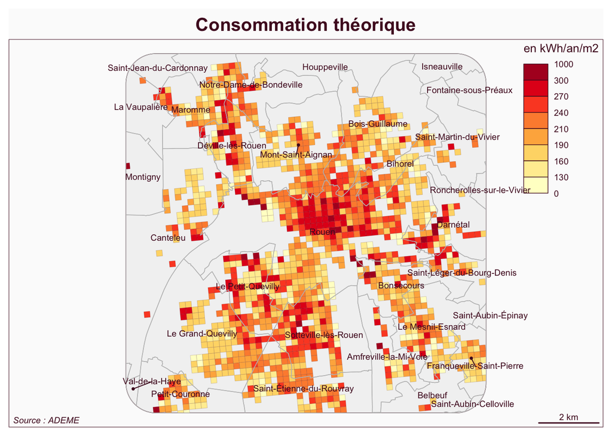

```r
mypal<-brewer.pal(8,"YlOrRd")
mybreaks <-c(00,130, 160, 190, 210, 240, 270, 300, 1000)
mf_map(buffer, type="base", col="gray95")
mf_map(mapgrid2,
       type = "choro",
       var = "EST",
       pal=mypal,
       breaks = mybreaks,
       leg_title = "en kWh/an/m2",
       leg_val_rnd = 0,
              lwd=0.1,
       add=T)
mf_map(mapcom, type="base", col=NA, border="gray",add=T)
mf_label(mapcom,var = "NOM",cex = 0.6,overlap = F )
mf_layout(title = "Consommation théorique",scale = T, arrow=F, frame=T,credits = "Source : ADEME")
```

### Consommation résiduelle

C’est la carte de la médiane des résidus de note modèle, c’est-à-dire les cas où la consommation de la zone est supérieure ou inférieure à ce que laissaient prévoir les variables introduites dans le modèle.

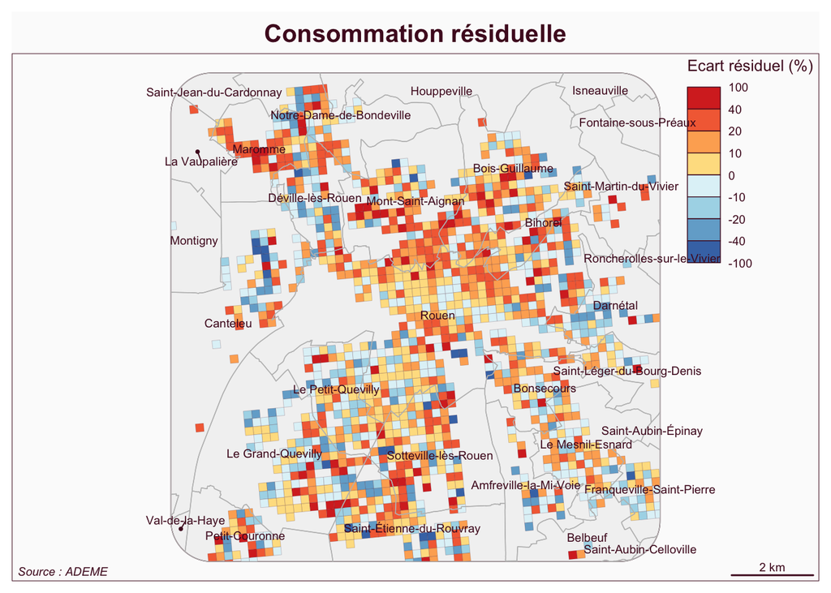

```r
mypal<-rev(brewer.pal(8,"RdYlBu"))
mybreaks <-c(-100, -40,-20, -10, 0,10, 20, 40,100)
mf_map(buffer, type="base", col="gray95")
mf_map(mapgrid2,
       type = "choro",
       var = "RES",
       pal=mypal,
       breaks = mybreaks,
       leg_title = "Ecart résiduel (%)",
       leg_val_rnd = 0,
              lwd=0.1,
       add=T)
mf_map(mapcom, type="base", col=NA, border="gray",add=T)
mf_label(mapcom,var = "NOM",cex = 0.6,overlap = F )
mf_layout(title = "Consommation résiduelle",scale = T, arrow=F, frame=T,credits = "Source : ADEME")
```